# Final exercise

Henrik Husberg

10/26/2020

# Longitudinal study - description

This is pilot data for an intervention study. The pilot was cut short because of the coronavirus pandemic and half the participants data was never submitted by the school. The plan is to simulate data in order to test analyses. We are currently collecting more data in order to be able to better simulate data. In this fist part, I’ll reda and present the (very) limited data we currently have.

```r
getwd()
```

```
## [1] "C:/Users/henri/Documents/GitHub/datavis-R/own"
```

```r
setwd("C:/Users/henri/Documents/GitHub/datavis-R/own")
fokus_p <- readr::read_csv2("fokus_p_dbr_wide_2.csv")
```

```
## Using ',' as decimal and '.' as grouping mark. Use read_delim() for more control.
```

```r
# Then have a look at the data
str(fokus_p)
```

```
## tibble [2 x 22] (S3: spec_tbl_df/tbl_df/tbl/data.frame)
##  $ id    : num [1:2] 1 2
##  $ gender: chr [1:2] "M" "F"
##  $ age   : num [1:2] 8.5 9.6
##  $ group : num [1:2] 0 1
##  $ ae0   : num [1:2] 9 6
##  $ ae1   : num [1:2] 6 3
##  $ ae2   : num [1:2] 7 4
##  $ ae3   : num [1:2] 2 999
##  $ ae4   : num [1:2] 6 7
##  $ ae5   : num [1:2] 7 5
##  $ ae6   : num [1:2] 5 3
##  $ ae7   : num [1:2] 4 999
##  $ ae8   : num [1:2] 7 6
##  $ ae9   : num [1:2] 999 4
##  $ ae10  : num [1:2] 999 5
##  $ ae11  : num [1:2] 999 5
##  $ ae12  : num [1:2] 1 7
##  $ ae13  : num [1:2] 1 6
##  $ ae14  : num [1:2] 8 9
##  $ ae15  : num [1:2] 999 6
##  $ ae16  : num [1:2] 999 4
##  $ ae17  : num [1:2] 999 7
##  - attr(*, "spec")=
##   .. cols(
##   ..   id = col_double(),
##   ..   gender = col_character(),
##   ..   age = col_double(),
##   ..   group = col_double(),
##   ..   ae0 = col_double(),
##   ..   ae1 = col_double(),
##   ..   ae2 = col_double(),
##   ..   ae3 = col_double(),
##   ..   ae4 = col_double(),
##   ..   ae5 = col_double(),
##   ..   ae6 = col_double(),
##   ..   ae7 = col_double(),
##   ..   ae8 = col_double(),
##   ..   ae9 = col_double(),
##   ..   ae10 = col_double(),
##   ..   ae11 = col_double(),
##   ..   ae12 = col_double(),
##   ..   ae13 = col_double(),
##   ..   ae14 = col_double(),
##   ..   ae15 = col_double(),
##   ..   ae16 = col_double(),
##   ..   ae17 = col_double()
##   .. )
```

```r
glimpse(fokus_p)
```

```
## Rows: 2
## Columns: 22
## $ id     <dbl> 1, 2
## $ gender <chr> "M", "F"
## $ age    <dbl> 8.5, 9.6
## $ group  <dbl> 0, 1
## $ ae0    <dbl> 9, 6
## $ ae1    <dbl> 6, 3
## $ ae2    <dbl> 7, 4
## $ ae3    <dbl> 2, 999
## $ ae4    <dbl> 6, 7
## $ ae5    <dbl> 7, 5
## $ ae6    <dbl> 5, 3
## $ ae7    <dbl> 4, 999
## $ ae8    <dbl> 7, 6
## $ ae9    <dbl> 999, 4
## $ ae10   <dbl> 999, 5
## $ ae11   <dbl> 999, 5
## $ ae12   <dbl> 1, 7
## $ ae13   <dbl> 1, 6
## $ ae14   <dbl> 8, 9
## $ ae15   <dbl> 999, 6
## $ ae16   <dbl> 999, 4
## $ ae17   <dbl> 999, 7
```

```r
#I'll want the data in long format for plotting of individual trajectories
library(tidyr)
fokus_p_l <- fokus_p %>% gather(time, dbr, -c(id, gender, age, group))

glimpse(fokus_p_l)
```

```
## Rows: 36
## Columns: 6
## $ id     <dbl> 1, 2, 1, 2, 1, 2, 1, 2, 1, 2, 1, 2, 1, 2, 1, 2, 1, 2, 1, 2, ...
## $ gender <chr> "M", "F", "M", "F", "M", "F", "M", "F", "M", "F", "M", "F", ...
## $ age    <dbl> 8.5, 9.6, 8.5, 9.6, 8.5, 9.6, 8.5, 9.6, 8.5, 9.6, 8.5, 9.6, ...
## $ group  <dbl> 0, 1, 0, 1, 0, 1, 0, 1, 0, 1, 0, 1, 0, 1, 0, 1, 0, 1, 0, 1, ...
## $ time   <chr> "ae0", "ae0", "ae1", "ae1", "ae2", "ae2", "ae3", "ae3", "ae4...
## $ dbr    <dbl> 9, 6, 6, 3, 7, 4, 2, 999, 6, 7, 7, 5, 5, 3, 4, 999, 7, 6, 99...
```

```r
# Then, I'll replace the 999:s with NA:s and change id and gender to factors

fokus_p_l <- fokus_p_l %>%
  mutate(dbr = na_if(dbr, 999)) %>%
  mutate(id = as.factor(id)) %>%
  mutate(gender = as.factor(gender))

glimpse(fokus_p_l)
```

```
## Rows: 36
## Columns: 6
## $ id     <fct> 1, 2, 1, 2, 1, 2, 1, 2, 1, 2, 1, 2, 1, 2, 1, 2, 1, 2, 1, 2, ...
## $ gender <fct> M, F, M, F, M, F, M, F, M, F, M, F, M, F, M, F, M, F, M, F, ...
## $ age    <dbl> 8.5, 9.6, 8.5, 9.6, 8.5, 9.6, 8.5, 9.6, 8.5, 9.6, 8.5, 9.6, ...
## $ group  <dbl> 0, 1, 0, 1, 0, 1, 0, 1, 0, 1, 0, 1, 0, 1, 0, 1, 0, 1, 0, 1, ...
## $ time   <chr> "ae0", "ae0", "ae1", "ae1", "ae2", "ae2", "ae3", "ae3", "ae4...
## $ dbr    <dbl> 9, 6, 6, 3, 7, 4, 2, NA, 6, 7, 7, 5, 5, 3, 4, NA, 7, 6, NA, ...
```

So the DV here is dbr (actually, there will be 3 dbr-measurements: dbr_ae, dbr_rb and dbr_db).

# Example of plot

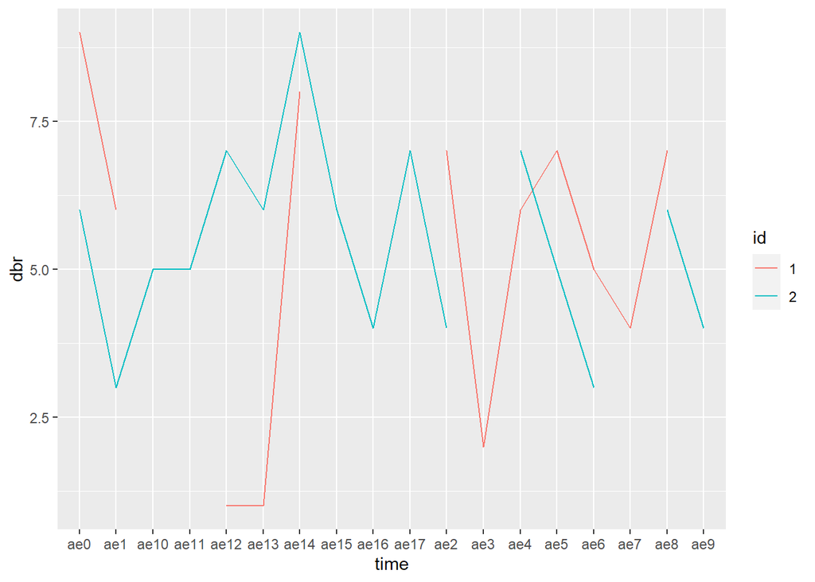

```r
fokus_p_l %>%
  ggplot(aes(x=time, y=dbr, group = id, color = id)) + geom_line()
```

# Simulating data

In order to practice visualization, and maybe even conduct power analysis, I’ll be simulating data. There is still much I (most) I don’t understand about simulating data, so in order to get started I’ve simply tried to recreate a dataframe of the size we’re hoping to collect, with (random) values according to the measurements.

```r
# simulating data

set.seed(1)
fpl_sim <- data.frame(id = rep(1:10, each = 72) %>% as.character,
                     time_p = rep(1:72, 10),
                     group = rep(1:2, each = 360),
                     age = rnorm(720, mean = 9, sd = 1),
                     gender = rep(1:2, 360),
                     dbr_ae = (sample.int(10, 720, replace = T) - 1)) %>%
    mutate(group = factor(group))

summary(fpl_sim)
```

```
##       id                time_p      group        age             gender
##  Length:720         Min.   : 1.00   1:360   Min.   : 5.992   Min.   :1.0
##  Class :character   1st Qu.:18.75   2:360   1st Qu.: 8.343   1st Qu.:1.0
##  Mode  :character   Median :36.50           Median : 8.944   Median :1.5
##                     Mean   :36.50           Mean   : 8.983   Mean   :1.5
##                     3rd Qu.:54.25           3rd Qu.: 9.678   3rd Qu.:2.0
##                     Max.   :72.00           Max.   :12.810   Max.   :2.0
##      dbr_ae
##  Min.   :0.0
##  1st Qu.:2.0
##  Median :5.0
##  Mean   :4.7
##  3rd Qu.:7.0
##  Max.   :9.0
```

```r
# introducing some missing data

# as.data.frame(lapply(fpl_sim, function(cc) cc[ sample(c(TRUE, NA), prob = c(0.85, 0.15), size = length(cc), replace = TRUE) ]))
# Can't get it to work for just one column, applies NA:s to all data...
```

What I would like to do, is introduce trends to the **dbr_ae** variable. What this trend looks like will become clearer during this year when we hopefully will be able to collect n=10 over the 72 measurements. Until then, I can only assume. I would like to introduce different trends to different timepoints (baseline phase (time_p 1:6), intervention phase (time_p 7:14), intensified phase (time_p 15:66) and follow-up phase (time_p 67:72)).

# Plotting individual trajectories

This, I will have to work on a lot still. For now, I’ll just demonstrate what a basic plot for 10 individuals would look like with completely random DV-values.

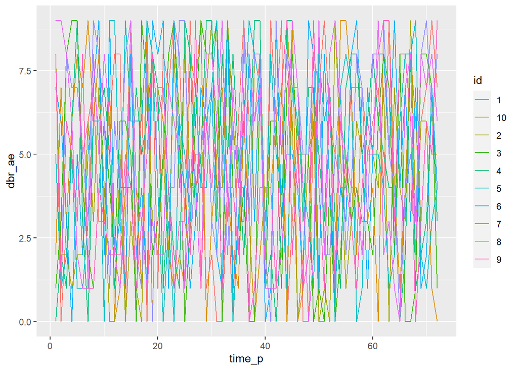

```r
fpl_sim %>%
  ggplot(aes(x=time_p, y=dbr_ae, group = id, color = id)) + geom_line()
```